# Power Simulation for Type I (Time) and Type II (Failure) Censored Weibull Data

by Robert Andrew Stevens, February 20, 2014

# Outline

1. Introduction: Background, Objective, Test Plan
2. Terminology
3. Tests: Summary, Binomial, Maximum Likelihood, Maximum Likelihood Constrained, Regression, Cox Proportional Hazards
4. Simulation: Why, Program
5. Results: By Test, Comparing Each Test
6. What's Next?

# 1. Introduction

## Background

Definition: Ozone layer

https://en.wikipedia.org/wiki/Ozone_layer

Problem: Ozone depletion potential

https://en.wikipedia.org/wiki/Ozone_depletion_potential

Original Air Conditioning Design Refrigerant: R-12

https://en.wikipedia.org/wiki/Dichlorodifluoromethane

Alternative Air Conditioning Design Refrigerant: R134a

https://en.wikipedia.org/wiki/R134a

## Objective

- Determine the probability of declaring two populations different for a given sample size
- Determine the required sample size to declare two populations different with a given probability

## Test Plan

- Drive two different groups of cars until they experience a failure or reach 100K miles
- Drive two different groups of cars until the original design experiences a predetermined number of failures

# 2. Terminology

- Alpha: Probability of declaring two populations different when they are actually the same. Also call the Type I error rate.
- Beta: Probability of declaring two populations the same when they are actually different. Also called the Type II error rate.
- Power: Probability of declaring two populations different when they are different (= 1 - Beta).
- Null Hypothesis (H0): The hypothesis that two populations are equal.
- Alternative Hypothesis (H1): The hypothesis that two populations are not equal.
- Censored: Suspended, removed from the test before failure occurs.
- Type I censoring: Each item remains on test until failure or until a specified time is reached (same for each item). Also called time censoring.
- Type II censoring: N items are put on test at the same time and testing continues until the Rth (R <= N) item fais.

# 3. Tests

## Tests, Test Statistics, and Rejection Criteria Summary

Binomial (based on 2x2 contingency table)

- BinStat = N*(N11*N2. - N21*N1.)<sup>2</sup> / (N.1*N.2*N1.*N2.) [without continuity correction]
- 2-sided: Reject H0 if BinStat > qchisq(1 - alpha, 1) [use alpha/2 ?]
- 1-sided: Reject H0 if P0 > P1 and BinStat > qchisq(1 - 2*alpha, 1) [use alpha ?]

Maximum Likelihood

- mleStat = 2*((lnL(Full) - lnL(Reduced))
- 2-sided: Reject H0 if mleStat > qchisq(1 - alpha, 2) [use alpha/2 ?]
- 1-sided: Reject H0 if Theta0 > Theta1 and mleStat > qchisq(1 - 2*alpha, 2) [use alpha ?]

Maximum Likelihood Constrained (assumes equal Weibull slope parameters)

- mlcStat = 2*(lnL(Full) - lnL(Reduced))
- 2-sided: Reject H0 if mlcStat > qchisq(1 - alpha, 1) [use alpha/2 ?]
- 1-sided: Reject H0 if Theta0 > Theta1 and mlcStat > qchisq(1 - 2*alpha, 1) [use alpha ?]

Regression

- regStat = (b/se(b))<sup>2</sup>
- 2-sided: Reject H0 if regStat > qchisq(1 - alpha, 1) [use alpha/2 ?]
- 1-sided: Reject H0 if b < 0 and regStat > qchisq(1 - 2*alpha, 1) [use alpha ?]

Cox Proportional Hazards

- cphStat = (b/se(b))<sup>2</sup>
- 2-sided: Reject H0 if cphStat > qchisq(1 - alpha, 1) [use alpha/2 ?]
- 1-sided: Reject H0 if b < 0 and cphStat > qchisq(1 - 2*alpha, 1) [use alpha ?]

Example:

- Sample = 0 if original design
- Sample = 1 if alternative design
- Time = Time to failure or time to censor (test stopped before failure)
- Censcode = 0 if censored (did not fail yet, i.e. Failed = FALSE)
- Censcode = 1 if failed (Failed = TRUE)

```r
library(survival)
setwd("C:\\Users\\rs62172\\Documents\\PowerSim\\")
data <- read.csv("PowerSimTest.csv", header = TRUE, sep = ",")  # sample data
data
```

```
##    Sample   Time Censcode
## 1       0 100.00        0
## 2       0  45.93        1
## 3       0 100.00        0
## 4       0  74.22        1
## 5       0 100.00        0
## 6       0  77.19        1
## 7       0 100.00        0
## 8       0 100.00        0
## 9       0  68.49        1
## 10      0 100.00        0
## 11      0  28.73        1
## 12      0  48.42        1
## 13      0  69.45        1
## 14      0 100.00        0
```

[output cut: 16 more lines]

```r
alpha = 0.1
```

## Binomial

```r
(dataTable <- table(data$Sample, data$Censcode))
```

```
##
##      0  1
##   0  8  7
##   1  4 11
```

```r
(BinTest <- chisq.test(dataTable, correct = FALSE))  # without continuity correction
```

```
##
##  Pearson's Chi-squared test
##
## data:  dataTable
## X-squared = 2.222, df = 1, p-value = 0.136
```

```r
(BinStat <- BinTest$statistic)
```

```
## X-squared
##     2.222
```

```r
# 2-sided
(BinCritical2 <- qchisq(1 - alpha, 1))
```

```
## [1] 2.706
```

```r
BinStat > BinCritical2
```

```
## X-squared
##     FALSE
```

```r
# 1-sided
(P0 <- dataTable[1, 1]/(dataTable[1, 1] + dataTable[1, 2]))
```

```
## [1] 0.5333
```

```r
(P1 <- dataTable[2, 1]/(dataTable[2, 1] + dataTable[2, 2]))
```

```
## [1] 0.2667
```

```r
P0 > P1
```

```
## [1] TRUE
```

```r
(BinCritical1 <- qchisq(1 - 2 * alpha, 1))
```

```
## [1] 1.642
```

```r
BinStat > BinCritical1
```

```
## X-squared
##      TRUE
```

## Maximum likelihood

```r
weibull0 <- survreg(Surv(Time, Censcode) ~ 1, data[data$Sample == 0, ], dist = "weibull")
summary(weibull0)
```

```
##
## Call:
## survreg(formula = Surv(Time, Censcode) ~ 1, data = data[data$Sample ==
##     0, ], dist = "weibull")
##              Value Std. Error     z         p
## (Intercept)  4.800      0.208 23.10 4.36e-118
## Log(scale)  -0.737      0.347 -2.13  3.33e-02
##
## Scale= 0.478
##
## Weibull distribution
## Loglik(model)= -41.3   Loglik(intercept only)= -41.3
## Number of Newton-Raphson Iterations: 5
## n= 15
```

```r
weibull1 <- survreg(Surv(Time, Censcode) ~ 1, data[data$Sample == 1, ], dist = "weibull")
summary(weibull1)
```

```
##
## Call:
## survreg(formula = Surv(Time, Censcode) ~ 1, data = data[data$Sample ==
##     1, ], dist = "weibull")
##              Value Std. Error     z         p
## (Intercept)  4.472      0.134 33.48 1.10e-245
## Log(scale)  -0.815      0.262 -3.11  1.87e-03
##
## Scale= 0.443
##
## Weibull distribution
## Loglik(model)= -57.7   Loglik(intercept only)= -57.7
## Number of Newton-Raphson Iterations: 5
## n= 15
```

```r
weibullR <- survreg(Surv(Time, Censcode) ~ 1, data, dist = "weibull")
summary(weibullR)
```

```
##
## Call:
## survreg(formula = Surv(Time, Censcode) ~ 1, data = data, dist = "weibull")
##              Value Std. Error     z        p
## (Intercept)  4.624      0.114 40.70 0.000000
## Log(scale)  -0.767      0.211 -3.64 0.000271
##
## Scale= 0.464
##
## Weibull distribution
## Loglik(model)= -100.1   Loglik(intercept only)= -100.1
## Number of Newton-Raphson Iterations: 5
## n= 30
```

```r
(mleStat <- 2 * ((weibull0$loglik[1] + weibull1$loglik[1]) - weibullR$loglik[1]))
```

```
## [1] 2.116
```

```r
# 2-sided
(mleCritical2 <- qchisq(1 - alpha, 2))
```

```
## [1] 4.605
```

```r
mleStat > mleCritical2
```

```
## [1] FALSE
```

```r
# 1-sided
(Theta0 <- exp(weibull0$coefficients))
```

```
## (Intercept)
##       121.6
```

```r
(Theta1 <- exp(weibull1$coefficients))
```

```
## (Intercept)
##       87.55
```

```r
Theta0 > Theta1
```

```
## (Intercept)
##        TRUE
```

```r
(mleCritical1 <- qchisq(1 - 2 * alpha, 2))
```

```
## [1] 3.219
```

```r
mleStat > mleCritical2
```

```
## [1] FALSE
```

## Maximum likelihood constrained

```r
weibullF <- survreg(Surv(Time, Censcode) ~ Sample, data, dist = "weibull")
summary(weibullF)
```

```
##
## Call:
## survreg(formula = Surv(Time, Censcode) ~ Sample, data = data,
##     dist = "weibull")
##              Value Std. Error     z         p
## (Intercept)  4.787      0.182 26.34 6.92e-153
## Sample      -0.314      0.226 -1.38  1.66e-01
## Log(scale)  -0.786      0.209 -3.76  1.71e-04
##
## Scale= 0.456
##
## Weibull distribution
## Loglik(model)= -99   Loglik(intercept only)= -100.1
##  Chisq= 2.08 on 1 degrees of freedom, p= 0.15
## Number of Newton-Raphson Iterations: 5
## n= 30
```

```r
weibullR <- survreg(Surv(Time, Censcode) ~ 1, data, dist = "weibull")
summary(weibullR)
```

```
##
## Call:
## survreg(formula = Surv(Time, Censcode) ~ 1, data = data, dist = "weibull")
##              Value Std. Error     z        p
## (Intercept)  4.624      0.114 40.70 0.000000
## Log(scale)  -0.767      0.211 -3.64 0.000271
##
## Scale= 0.464
##
## Weibull distribution
## Loglik(model)= -100.1   Loglik(intercept only)= -100.1
## Number of Newton-Raphson Iterations: 5
## n= 30
```

```r
(mlcStat <- 2 * (weibullF$loglik[2] - weibullR$loglik[1]))
```

```
## [1] 2.084
```

```r
# 2-sided
(mlcCritical2 <- qchisq(1 - alpha, 1))
```

```
## [1] 2.706
```

```r
mlcStat > mlcCritical2
```

```
## [1] FALSE
```

```r
# 1-sided
(Theta0 <- exp(weibullF$coefficients[1]))
```

```
## (Intercept)
##       119.9
```

```r
(Theta1 <- exp(weibullF$coefficients[1] + weibullF$coefficients[2]))
```

```
## (Intercept)
##       87.61
```

```r
Theta0 > Theta1
```

```
## (Intercept)
##        TRUE
```

```r
(mlcCritical1 <- qchisq(1 - 2 * alpha, 1))
```

```
## [1] 1.642
```

```r
mlcStat > mleCritical1
```

```
## [1] FALSE
```

## Regression

```r
weibullF <- survreg(Surv(Time, Censcode) ~ Sample, data, dist = "weibull")
summary(weibullF)
```

```
##
## Call:
## survreg(formula = Surv(Time, Censcode) ~ Sample, data = data,
##     dist = "weibull")
##              Value Std. Error     z         p
## (Intercept)  4.787      0.182 26.34 6.92e-153
## Sample      -0.314      0.226 -1.38  1.66e-01
## Log(scale)  -0.786      0.209 -3.76  1.71e-04
##
## Scale= 0.456
##
## Weibull distribution
## Loglik(model)= -99   Loglik(intercept only)= -100.1
##  Chisq= 2.08 on 1 degrees of freedom, p= 0.15
## Number of Newton-Raphson Iterations: 5
## n= 30
```

```r
(b1 <- weibullF$coefficients[2])
```

```
##  Sample
## -0.3136
```

```r
(regStat <- (b1/sqrt(weibullF$var[2, 2]))^2)
```

```
## Sample
##  1.918
```

```r
# 2-sided
(regCritical2 <- qchisq(1 - alpha, 1))
```

```
## [1] 2.706
```

```r
regStat > regCritical2
```

```
## Sample
##  FALSE
```

```r
# 1-sided
b1 < 0
```

```
## Sample
##   TRUE
```

```r
(regCritical1 <- qchisq(1 - 2 * alpha, 1))
```

```
## [1] 1.642
```

```r
regStat > regCritical1
```

```
## Sample
##   TRUE
```

## Cox Proportional Hazards

```r
coxphF <- coxph(Surv(Time, Censcode) ~ Sample, data)
summary(coxphF)
```

```
## Call:
## coxph(formula = Surv(Time, Censcode) ~ Sample, data = data)
##
##   n= 30, number of events= 18
##
##         coef exp(coef) se(coef)    z Pr(>|z|)
## Sample 0.627     1.871    0.484 1.29      0.2
##
##        exp(coef) exp(-coef) lower .95 upper .95
## Sample      1.87      0.534     0.724      4.83
##
## Concordance= 0.577  (se = 0.063 )
## Rsquare= 0.056   (max possible= 0.974 )
## Likelihood ratio test= 1.73  on 1 df,   p=0.189
## Wald test            = 1.67  on 1 df,   p=0.196
## Score (logrank) test = 1.73  on 1 df,   p=0.188
```

```r
(b1 <- coxphF$coefficients)
```

```
## Sample
## 0.6266
```

```r
(cphStat <- (b1/sqrt(coxphF$var))^2)
```

```
##       [,1]
## [1,] 1.674
```

```r
# 2-sided
(cphCritical2 <- qchisq(1 - alpha, 1))
```

```
## [1] 2.706
```

```r
cphStat > cphCritical2
```

```
##       [,1]
## [1,] FALSE
```

```r
# 1-sided
b1 > 0
```

```
## Sample
##   TRUE
```

```r
(cphCritical1 <- qchisq(1 - 2 * alpha, 1))
```

```
## [1] 1.642
```

```r
cphStat > cphCritical1
```

```
##      [,1]
## [1,] TRUE
```

# 4. Simulation

## Why

Why do a simulation? Quotes from *Statistical Models and Methods for Lifetime Data* by Lawless (1982, p. 195-7):

Life test plans under the Weibull model **have not been very thoroughly investigated**, however, because of the complexity of the associated distributional problems. This is unfortunate and sometimes leads to the use of plans based on the exponential distribution when plans based on the Weibull distributions would be more appropriate.

Even for quite complicated plans the large-sample methods given for Type I censored data generally provide valid procedures. However, it is almost always impossible to determine exact small-sample properties or to make effective compariison of plans, **except by simulation**.

Further development of test plans under a Weibull model would be useful. Plans for comparing distributions are also of interest. Thoman and Bain (1969) present a few power functions for two-sample problems, **but not a great deal is available**…

## Program

First need to write functions for each statistical test:

- binTest = Binomial Test
- mleTest = Maximum Likelihood Test
- mlcTest = Maximum Likelihood Constrained Test
- regTest = Regression Test
- cphTest = Cox Proportional Hazards Test

Need to commonize the functions, i.e. use same names in data frame that is returned to the simulation.

But only need “decision1” and “decision2” returned from the functions, with TRUE = 1 and FALSE = 0 to perform calculations on the results.

```r
binTest <- function(Sample, Time, Censcode, a) {
    dataTable <- table(Sample, Censcode)
    binTest <- chisq.test(dataTable, correct = FALSE)
    testStat <- binTest$statistic
    # 2-sided
    critical2 <- qchisq(1 - a, 1)
    decision2 <- ifelse(testStat > critical2, 1, 0)
    # 1-sided
    p0 <- dataTable[1, 1]/(dataTable[1, 1] + dataTable[1, 2])
    p1 <- dataTable[2, 1]/(dataTable[2, 1] + dataTable[2, 2])
    delta <- p0 - p1
    critical1 <- qchisq(1 - 2 * a, 1)
    decision1 <- ifelse(delta > 0 & testStat > critical1, 1, 0)
    return(list(decision1 = decision1, decision2 = decision2))
}

mleTest <- function(Sample, Time, Censcode, a) {
    data <- data.frame(Sample, Time, Censcode)
    weibull0 <- survreg(Surv(Time, Censcode) ~ 1, data[data$Sample == 0, ],
        dist = "weibull")
    weibull1 <- survreg(Surv(Time, Censcode) ~ 1, data[data$Sample == 1, ],
        dist = "weibull")
    weibullR <- survreg(Surv(Time, Censcode) ~ 1, data, dist = "weibull")
    testStat <- 2 * ((weibull0$loglik[1] + weibull1$loglik[1]) - weibullR$loglik[1])
    # 2-sided
    critical2 <- qchisq(1 - a, 2)
    decision2 <- ifelse(testStat > critical2, 1, 0)
    # 1-sided
    theta0 <- exp(weibull0$coefficients)
    theta1 <- exp(weibull1$coefficients)
    delta <- theta0 - theta1
    critical1 <- qchisq(1 - 2 * a, 2)
    decision1 <- ifelse(delta > 0 & testStat > critical2, 1, 0)
    return(list(decision1 = decision1, decision2 = decision2))
}

mlcTest <- function(Sample, Time, Censcode, a) {
    weibullF <- survreg(Surv(Time, Censcode) ~ Sample, dist = "weibull")
    weibullR <- survreg(Surv(Time, Censcode) ~ 1, dist = "weibull")
    testStat <- 2 * (weibullF$loglik[2] - weibullR$loglik[1])
    # 2-sided
    critical2 <- qchisq(1 - a, 1)
    decision2 <- ifelse(testStat > critical2, 1, 0)
    # 1-sided
    theta0 <- exp(weibullF$coefficients[1])
    theta1 <- exp(weibullF$coefficients[1] + weibullF$coefficients[2])
    delta <- theta0 - theta1
    critical1 <- qchisq(1 - 2 * a, 1)
    decision1 <- ifelse(delta > 0 & testStat > critical1, 1, 0)
    return(list(decision1 = decision1, decision2 = decision2))
}

regTest <- function(Sample, Time, Censcode, a) {
    weibullF <- survreg(Surv(Time, Censcode) ~ Sample, dist = "weibull")
    delta <- weibullF$coefficients[2]
    testStat <- (delta/sqrt(weibullF$var[2, 2]))^2
    # 2-sided
    critical2 <- qchisq(1 - a, 1)
    decision2 <- ifelse(testStat > critical2, 1, 0)
    # 1-sided
    critical1 <- qchisq(1 - 2 * a, 1)
    decision1 <- ifelse(delta < 0 & testStat > critical1, 1, 0)
    return(list(decision1 = decision1, decision2 = decision2))
}

cphTest <- function(Sample, Time, Censcode, a) {
    coxph <- coxph(Surv(Time, Censcode) ~ Sample)
    delta <- coxph$coefficients
    testStat <- (delta/sqrt(coxph$var))^2
    # 2-sided
    critical2 <- qchisq(1 - a, 1)
    decision2 <- ifelse(testStat > critical2, 1, 0)
    # 1-sided
    critical1 <- qchisq(1 - 2 * a, 1)
    decision1 <- ifelse(delta > 0 & testStat > critical1, 1, 0)
    return(list(decision1 = decision1, decision2 = decision2))
}

with(data, binTest(Sample, Time, Censcode, alpha))
```

```
## $decision1
## X-squared
##         1
##
## $decision2
## X-squared
##         0
```

```r
with(data, mleTest(Sample, Time, Censcode, alpha))
```

```
## $decision1
## (Intercept)
##           0
##
## $decision2
## [1] 0
```

```r
with(data, mlcTest(Sample, Time, Censcode, alpha))
```

```
## $decision1
## (Intercept)
##           1
##
## $decision2
## [1] 0
```

```r
with(data, regTest(Sample, Time, Censcode, alpha))
```

```
## $decision1
## Sample
##      1
##
## $decision2
## Sample
##      0
```

```r
with(data, cphTest(Sample, Time, Censcode, alpha))
```

```
## $decision1
##      [,1]
## [1,]    1
##
## $decision2
##      [,1]
## [1,]    0
```

Now need to write a function to generate random values from Weibull distribution and censor them for both Plan 1 (Type I or time censoring) and Plan 2 (Type II or failure censoring).

```r
lifedata <- function(alpha, beta, cdf1, cdf2, size, testTime) {

    theta1 <- testTime/((-log(1 - cdf1))^(1/beta))
    theta2 <- testTime/((-log(1 - cdf2))^(1/beta))

    sampleVec <- c(rep(0, size), rep(1, size))
    obsVec <- rep(seq(1, size, 1), 2)

    timeVec1 <- rweibull(size, beta, theta1)
    timeVec2 <- rweibull(size, beta, theta2)
    time1Vec <- c(timeVec1, timeVec2)
    time2Vec <- c(timeVec1, timeVec2)
    cens1Vec <- rep(1, 2 * size)  # initialize to 1
    cens2Vec <- rep(1, 2 * size)  # initialize to 1

    censored1 <- ifelse(time1Vec > testTime, TRUE, FALSE)
    time1Vec[censored1] <- testTime
    cens1Vec[censored1] <- 0

    rankVec1 <- rank(timeVec1)
    rankVec2 <- rank(timeVec2)
    rankVec <- c(rankVec1, rankVec2)

    ranktime <- ceiling(cdf1 * size)
    cens2time <- timeVec1[which(rankVec1 == ranktime)]  # Type II censoring time

    censored2 <- ifelse(time2Vec > cens2time, TRUE, FALSE)
    time2Vec[censored2] <- cens2time
    cens2Vec[censored2] <- 0

    df <- data.frame(sample = sampleVec, obs = obsVec, time1 = time1Vec, cens1 = cens1Vec,
        rank = rankVec, time2 = time2Vec, cens2 = cens2Vec)
}
```

Now ready for the simulation - try 500 to start

```r
set.seed(56497)
CDF1 <- 0.4
nSim <- 500
slope <- 2
sampleSize <- 15
tTime <- 100
Alpha <- 0.1

CDF2 <- seq(CDF1, 0.9, 0.05)
simSize <- length(CDF2) * nSim

results <- data.frame(Alpha = rep(Alpha, simSize), Slope = rep(slope, simSize),
    CDF1 = rep(CDF1, simSize), CDF2 = rep(CDF2, nSim), samples = rep(sampleSize,
        nSim), tTime = rep(tTime, simSize), bin11 = rep(0, simSize), bin12 = rep(0,
        simSize), bin21 = rep(0, simSize), bin22 = rep(0, simSize), mle11 = rep(0,
        simSize), mle12 = rep(0, simSize), mle21 = rep(0, simSize), mle22 = rep(0,
        simSize), mlc11 = rep(0, simSize), mlc12 = rep(0, simSize), mlc21 = rep(0,
        simSize), mlc22 = rep(0, simSize), reg11 = rep(0, simSize), reg12 = rep(0,
        simSize), reg21 = rep(0, simSize), reg22 = rep(0, simSize), cph11 = rep(0,
        simSize), cph12 = rep(0, simSize), cph21 = rep(0, simSize), cph22 = rep(0,
        simSize))
```

For the next part, would like to find a way to do this without a “for” loop and using data frame column names, not numbers. Suppressed the warnings, but they should be investigated.

```r
for (i in seq(1:simSize)) {
    testData <- with(results[i, ], lifedata(Alpha, Slope, CDF1, CDF2, samples,
        tTime))
    results[i, 7] <- with(testData, binTest(sample, time1, cens1, Alpha))$decision1
    results[i, 8] <- with(testData, binTest(sample, time1, cens1, Alpha))$decision2
    results[i, 9] <- with(testData, binTest(sample, time2, cens2, Alpha))$decision1
    results[i, 10] <- with(testData, binTest(sample, time2, cens2, Alpha))$decision2
    results[i, 11] <- with(testData, mleTest(sample, time1, cens1, Alpha))$decision1
    results[i, 12] <- with(testData, mleTest(sample, time1, cens1, Alpha))$decision2
    results[i, 13] <- with(testData, mleTest(sample, time2, cens2, Alpha))$decision1
    results[i, 14] <- with(testData, mleTest(sample, time2, cens2, Alpha))$decision2
    results[i, 15] <- with(testData, mlcTest(sample, time1, cens1, Alpha))$decision1
    results[i, 16] <- with(testData, mlcTest(sample, time1, cens1, Alpha))$decision2
    results[i, 17] <- with(testData, mlcTest(sample, time2, cens2, Alpha))$decision1
    results[i, 18] <- with(testData, mlcTest(sample, time2, cens2, Alpha))$decision2
    results[i, 19] <- with(testData, regTest(sample, time1, cens1, Alpha))$decision1
    results[i, 20] <- with(testData, regTest(sample, time1, cens1, Alpha))$decision2
    results[i, 21] <- with(testData, regTest(sample, time2, cens2, Alpha))$decision1
    results[i, 22] <- with(testData, regTest(sample, time2, cens2, Alpha))$decision2
    results[i, 23] <- with(testData, cphTest(sample, time1, cens1, Alpha))$decision1
    results[i, 24] <- with(testData, cphTest(sample, time1, cens1, Alpha))$decision2
    results[i, 25] <- with(testData, cphTest(sample, time2, cens2, Alpha))$decision1
    results[i, 26] <- with(testData, cphTest(sample, time2, cens2, Alpha))$decision2
}
```

# 5. Results

Combine/stack test results for the 5 tests to show combinations of lines on the same plots, using the follow naming convention:

- 11 = Type I censored data, 1-sided hypothesis test
- 12 = Type I censored data, 2-sided hypothesis test
- 21 = Type II censored data, 1-sided hypothesis test
- 22 = Type II censored data, 2-sided hypothesis test

Plotting function to minimize the code:

```r
plotNTests <- function(simData, plotTitle, plotVars) {
    require(ggplot2)  # for 'gglot'
    require(reshape2)  # for 'melt'
    # id.vars = all the variables to keep but not split apart on measure.vars =
    # source columns variable.name = name of the destination column that will
    # identify the original column that the measurement came from value.name =
    # value of variable.name
    plotData <- melt(simData, id.vars = c("Alpha", "Slope", "CDF1", "CDF2",
        "samples"), measure.vars = plotVars, variable.name = "Test", value.name = "Reject")
    testAgg <- aggregate(Reject ~ Test + CDF2, plotData, mean)
    ggplot(testAgg, aes(y = Reject, x = CDF2, color = Test)) + geom_smooth(data = testAgg,
        method = loess, se = FALSE) + scale_x_continuous(breaks = seq(0.4, 0.9,
        0.1)) + scale_y_continuous(breaks = seq(0, 1, 0.1), limits = c(0, 1)) +
        labs(title = plotTitle, x = "Sample 2 Failure Proportion", y = "Probability Reject")
}
```

## Results By Test: bin, mle, mlc, reg, cph

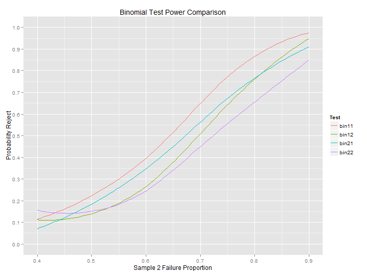

```r
plotTitle <- "Binomial Test Power Comparison"
plotVars <- c("bin11", "bin12", "bin21", "bin22")
plotNTests(results, plotTitle, plotVars)
```

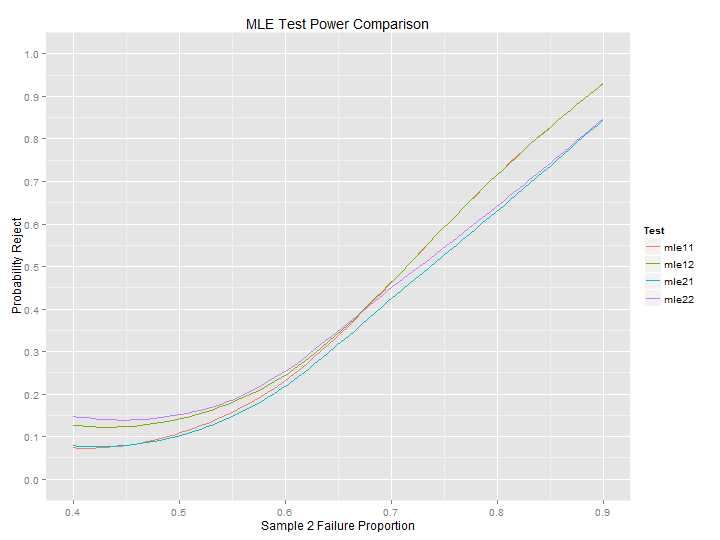

```r
plotTitle <- "MLE Test Power Comparison"
plotVars <- c("mle11", "mle12", "mle21", "mle22")
plotNTests(results, plotTitle, plotVars)
```

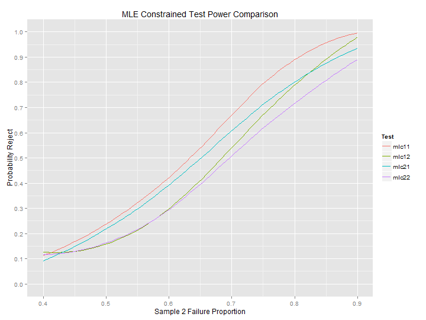

```r
plotTitle <- "MLE Constrained Test Power Comparison"
plotVars <- c("mlc11", "mlc12", "mlc21", "mlc22")
plotNTests(results, plotTitle, plotVars)
```

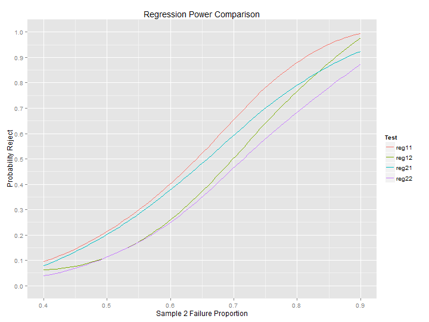

```r
plotTitle <- "Regression Power Comparison"
plotVars <- c("reg11", "reg12", "reg21", "reg22")
plotNTests(results, plotTitle, plotVars)
```

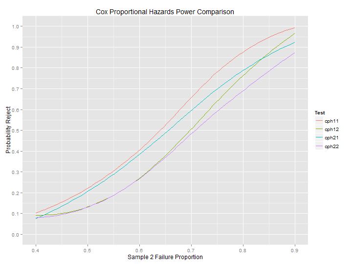

```r
plotTitle <- "Cox Proportional Hazards Power Comparison"
plotVars <- c("cph11", "cph12", "cph21", "cph22")
plotNTests(results, plotTitle, plotVars)
```

## Results Comparing Each Test

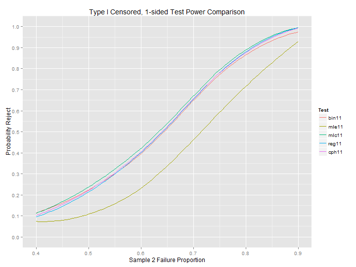

```r
plotTitle <- "Type I Censored, 1-sided Test Power Comparison"
plotVars <- c("bin11", "mle11", "mlc11", "reg11", "cph11")
plotNTests(results, plotTitle, plotVars)
```

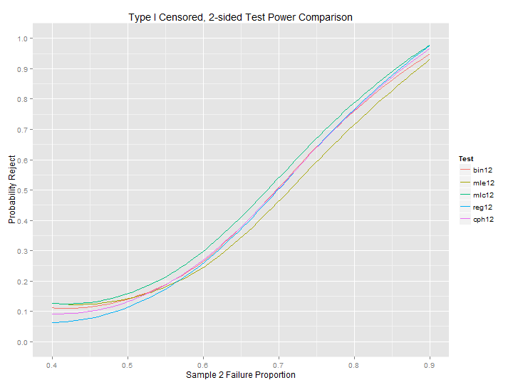

```r
plotTitle <- "Type I Censored, 2-sided Test Power Comparison"
plotVars <- c("bin12", "mle12", "mlc12", "reg12", "cph12")
plotNTests(results, plotTitle, plotVars)
```

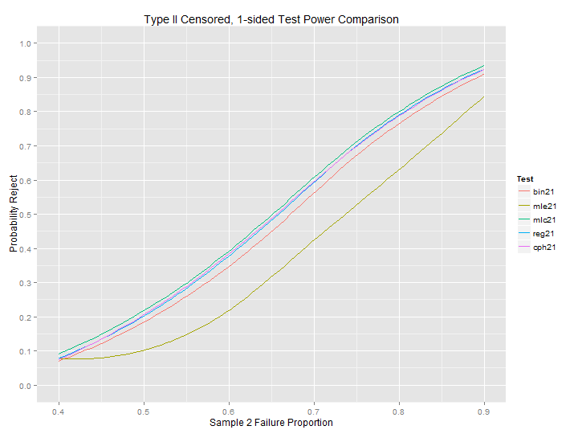

```r
plotTitle <- "Type II Censored, 1-sided Test Power Comparison"
plotVars <- c("bin21", "mle21", "mlc21", "reg21", "cph21")
plotNTests(results, plotTitle, plotVars)
```

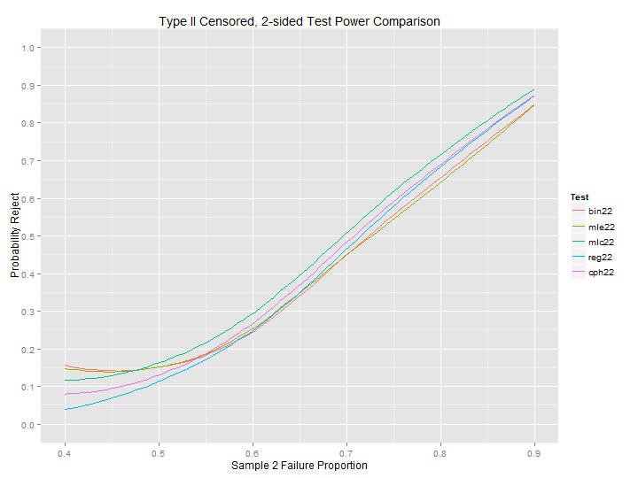

```r
plotTitle <- "Type II Censored, 2-sided Test Power Comparison"
plotVars <- c("bin22", "mle22", "mlc22", "reg22", "cph22")
plotNTests(results, plotTitle, plotVars)
```

# 6. What's Next?

- Investigate warnings: Chi-squared approximation may be incorrect, Ran out of iterations and did not converge, Loglik converged before variable 1 ; beta may be infinite.
- Check/confirm results, especially Type I error rates (alpha)
- Add variable sample sizes, e.g. 15, 20, 25, etc.
- Explore ways to speed up the simulation: better programming techniques (e.g. alternative to “for” loop) and parallel computing
- Are there packages available that offer improvments or more functionality? E.g. ClinicalTrials Task view
- Bayesian approaches?

**Any suggestions?**